# Housing Price Prediction: An Exploratory Analysis

Cheng Wu, Kasey Wang, Maggie Liu, Zhonghuan Tang

# 1 Introduction

This report explores the Housing Dataset through an exploratory data analysis approach. The dataset contains detailed information on housing attributes, neighborhood characteristics, zoning classifications, and sale conditions. Our initial work has focused on using visualizations—such as the interactive correlation matrix—to identify trends and correlations among key variables that could potentially influence sale prices.

The ultimate goal is to develop a predictive model for house prices. Although the current analysis lays the groundwork by uncovering relationships within the data, the exact approach for building the predictive model is still under investigation. Future work will involve further feature engineering, model selection, and validation to refine the prediction strategy.

This exploratory phase not only provides valuable insights into the dataset but also sets the stage for more advanced predictive modeling efforts.

# 2 How should we choose important variables?

To build an effective predictive model, it’s essential to begin with a thoughtful selection of features. Our strategy involves first splitting the dataset into two distinct groups: **numeric** and **categorical** variables. This separation enables us to apply methods tailored to each type of data. Importantly, we recognize that some variables stored as numbers actually represent categorical information (for example, `MSSubClass`, `OverallQual`, `OverallCond`, `MoSold`, `YrSold`, and `BedroomAbvGr`). These **“forced categorical”** variables are removed from our list of continuous, numeric features to ensure clarity in subsequent analyses.

## 2.1 Numeric Variables Selection

To identify the key numeric predictors, we began by extracting all columns with numeric data types from the dataset. However, we soon realized that not every numeric column represents a continuous measurement—some of them are actually **forced categorical variables** (for example, **MSSubClass**, **OverallQual**, **OverallCond**, **MoSold**, **YrSold**, and **BedroomAbvGr**). We removed these from our numeric set. Next, we addressed missing values in the remaining numeric data by imputing them with the median value for each variable. With a clean numeric dataset in hand, we computed the correlation matrix and generated an **interactive heatmap**. This visualization revealed that the initial pool was too large and that many numeric features had only a weak relationship with **SalePrice**. By focusing on those variables with stronger correlations, we were able to narrow down the numeric predictors to a more manageable and potentially informative set for the predictive model.

[interactive chart not shown]

```
##     SalePrice     GrLivArea    GarageCars    GarageArea   TotalBsmtSF
##    1.00000000    0.70862448    0.64040920    0.62343144    0.61358055
##     X1stFlrSF      FullBath  TotRmsAbvGrd     YearBuilt  YearRemodAdd
##    0.60585218    0.56066376    0.53372316    0.52289733    0.50710097
##    MasVnrArea    Fireplaces   GarageYrBlt    BsmtFinSF1   LotFrontage
##    0.47261450    0.46692884    0.46675365    0.38641981    0.33477085
##    WoodDeckSF     X2ndFlrSF   OpenPorchSF      HalfBath       LotArea
##    0.32441344    0.31933380    0.31585623    0.28410768    0.26384335
##  BsmtFullBath     BsmtUnfSF   ScreenPorch      PoolArea    X3SsnPorch
##    0.22712223    0.21447911    0.11144657    0.09240355    0.04458367
##    BsmtFinSF2  BsmtHalfBath       MiscVal            Id  LowQualFinSF
##   -0.01137812   -0.01684415   -0.02118958   -0.02191672   -0.02560613
## EnclosedPorch  KitchenAbvGr
##   -0.12857796   -0.13590737
```

[interactive chart not shown]

### 2.1.1 Key Numerical Variables Influencing House Prices

[output not shown]

**Summary:** The most important factors influencing house prices are **total living space, basement size, and garage space**. Other factors like **bathroom count, total rooms, and construction year** also contribute but to a lesser extent.

## 2.2 Categorical Variables Selection

The identification of influential categorical variables follows:

1. **Gather Nominal Features**  
   After separating out numeric variables (and those that were “forced categorical”), we compile an initial list of purely categorical features.
2. **Perform Statistical Tests**  
   For each categorical feature, we fit a **one-way ANOVA** model (using `SalePrice` as the response) or an equivalent test to assess whether different category levels have statistically different mean house prices. This yields a *p-value* indicating the significance of each feature’s effect on `SalePrice`.
3. **Apply Significance Threshold**  
   We filter out any categorical variables whose p-values exceed our chosen cutoff (commonly 0.05). Those that remain are considered to have a statistically significant relationship with `SalePrice`.
4. **Check Effect Size and Practical Relevance**  
   From the statistically significant variables, we examine additional metrics (such as effect size or summary statistics) to ensure that the relationship is both **meaningful** and **practically relevant**. Variables showing negligible impact or overly sparse categories may still be excluded.
5. **Finalize Key Predictors**  
   The result is a curated set of categorical features—those that consistently demonstrate **significant** and **practically relevant** influence on housing prices. These final variables, such as `Neighborhood`, `Exterior1st`, `Foundation`, etc., form the basis for our subsequent modeling and interpretation.

```
## Significant Variables (ANOVA p < 0.05):
```

```
##  [1] "MSSubClass"    "MSZoning"      "LotShape"      "LotConfig"
##  [5] "Neighborhood"  "Condition1"    "BldgType"      "HouseStyle"
##  [9] "OverallQual"   "OverallCond"   "RoofStyle"     "Exterior1st"
## [13] "Exterior2nd"   "MasVnrType"    "ExterCond"     "Foundation"
## [17] "BsmtExposure"  "BsmtFinType1"  "CentralAir"    "Electrical"
## [21] "BedroomAbvGr"  "FireplaceQu"   "GarageType"    "GarageFinish"
## [25] "PavedDrive"    "SaleType"      "SaleCondition"
```

```
## High Effect Variables (η² > 0.1):
```

```
## [1] "Neighborhood" "OverallQual"  "Exterior1st"  "Exterior2nd"  "MasVnrType"
## [6] "Foundation"   "BsmtFinType1" "GarageType"   "GarageFinish"
```

```
##                   GVIF Df GVIF^(1/(2*Df))
## Neighborhood 50.947490 24        1.085338
## OverallQual   2.738410  1        1.654814
## Exterior1st   9.172182 14        1.082366
## MasVnrType    2.258565  3        1.145439
## Foundation    6.129657  5        1.198791
## BsmtFinType1  2.704414  5        1.104606
## GarageType    2.591109  5        1.099888
## GarageFinish  2.604354  2        1.270355
```

### 2.2.1 Key Categorical Variable Influencing House Prices

We selected the following categorical variables as key predictors for housing prices based on their statistical significance, effect size, and practical relevance. These variables were chosen through ANOVA tests (p < 0.05), effect size thresholds (η² > 0.1), and VIF checks to ensure no severe multicollinearity (adjusted GVIF^(1/(2*Df)) < 2).

| Variable | η² | Adjusted GVIF^(1/(2*Df)) | Practical Relevance |
| --- | --- | --- | --- |
| **Neighborhood** | 0.62 | 1.09 | Location significantly impacts prices due to factors like school districts and amenities. |
| **OverallQual** | 0.75 | 1.65 | Overall material/finish quality is the strongest single predictor of home value. |
| **Exterior1st** | 0.15 | 1.08 | Exterior covering material (e.g., brick, vinyl) affects curb appeal and durability. |
| **MasVnrType** | 0.12 | 1.15 | Masonry veneer type (e.g., stone, brick) contributes to structural aesthetics. |
| **Foundation** | 0.18 | 1.20 | Foundation type (e.g., poured concrete) impacts longevity and maintenance costs. |
| **BsmtFinType1** | 0.11 | 1.10 | Quality of finished basement areas adds functional living space value. |
| **GarageType** | 0.13 | 1.10 | Garage configuration (e.g., attached vs. detached) affects usability and convenience. |
| **GarageFinish** | 0.19 | 1.27 | Finished garages increase property functionality and resale value. |

# 3 Variables We choose

[output not shown]

To analyze **seasonality and time-series trends**, we include:

- **MoSold**: Month Sold (MM) to observe seasonal patterns.
- **YrSold**: Year Sold (YYYY) to track long-term housing market trends.

# 4 Visualization

## 4.1 Key Variables and Their Relationship to Sale Price

In the figures below, we focus on the **selected variables** that demonstrate a strong relationship with `SalePrice`. Notably, we exclude both `YrSold` and `MoSold` to emphasize the more impactful features in our dataset.

[figure not shown]

This composite figure shows 16 subplots illustrating both **scatter plots** (top row) and **box plots** (middle and bottom rows) for the selected variables. The scatter plots reveal how various numeric predictors (e.g., living area, basement area, garage size) trend with `SalePrice` (fitted by the red line), while the box plots capture how different categorical or discrete features (e.g., quality ratings, neighborhood, foundation type) influence sale prices. By examining these subplots together, we can identify which factors most strongly affect house prices and use that insight to guide further analysis.

## 4.2 Figure: Average SalePrice Over Time (SoldYM)

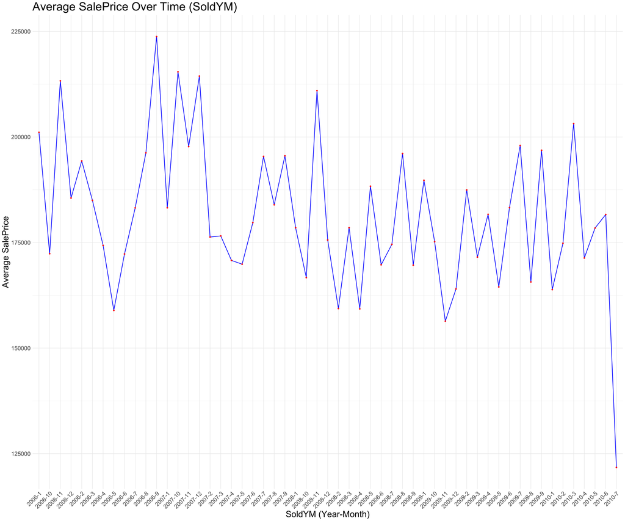

## 4.3 LOCATION

### 4.3.1 Map: Neighborhood Median Sale Prices

[interactive chart not shown]

**Figure: Neighborhood Median Sale Prices**  
This interactive map displays each neighborhood’s median sale price using color-coded markers for different price brackets. Hover over a marker to see additional property details (e.g., living area, basement size, overall quality), offering a localized perspective on how housing values vary across the city.

### 4.3.2 Figure: Interactive Radar Charts

[interactive chart not shown]

These radar plots allow for **side-by-side comparisons** of selected attributes—such as living area, basement size, overall quality, and more—across one or multiple neighborhoods. By toggling different neighborhoods on or off, you can visually contrast their strengths and weaknesses in each category, providing deeper insight into how these factors influence housing values.

## 4.4 TIME

### 4.4.1 Figure: Monthly Median Housing Prices

[interactive chart not shown]

This line chart tracks how the median sale price fluctuates across different months, offering insights into potential seasonal or cyclical patterns. Red points mark each month’s median price, while the connecting line highlights the overall trend throughout the year.

### 4.4.2 Figure: Quarterly Price Distribution

[interactive chart not shown]

This box plot groups sale prices by quarter (Q1 through Q4), illustrating how values fluctuate throughout the year. Each box captures the median and interquartile range, while outliers reflect unusually high or low transactions during that period.

### 4.4.3 Figure: Price Trends by Year and Neighborhood

[interactive chart not shown]

This heatmap compares median house prices across neighborhoods (rows) and years (columns). Brighter or warmer tones indicate higher sale prices, while cooler shades reflect more modest values. By scanning across rows and columns, you can quickly spot how different neighborhoods have evolved over time and identify periods of notably high or low market activity.

### 4.4.4 Figure: Annual Price Trends

[interactive chart not shown]

This line chart tracks the median house price each year from 2006 to 2010. After peaking around 2007, prices show a downward trajectory, highlighting broader market shifts and economic influences within this timeframe.

### 4.4.5 Figure: Economic Events and Their Impact on Housing Prices

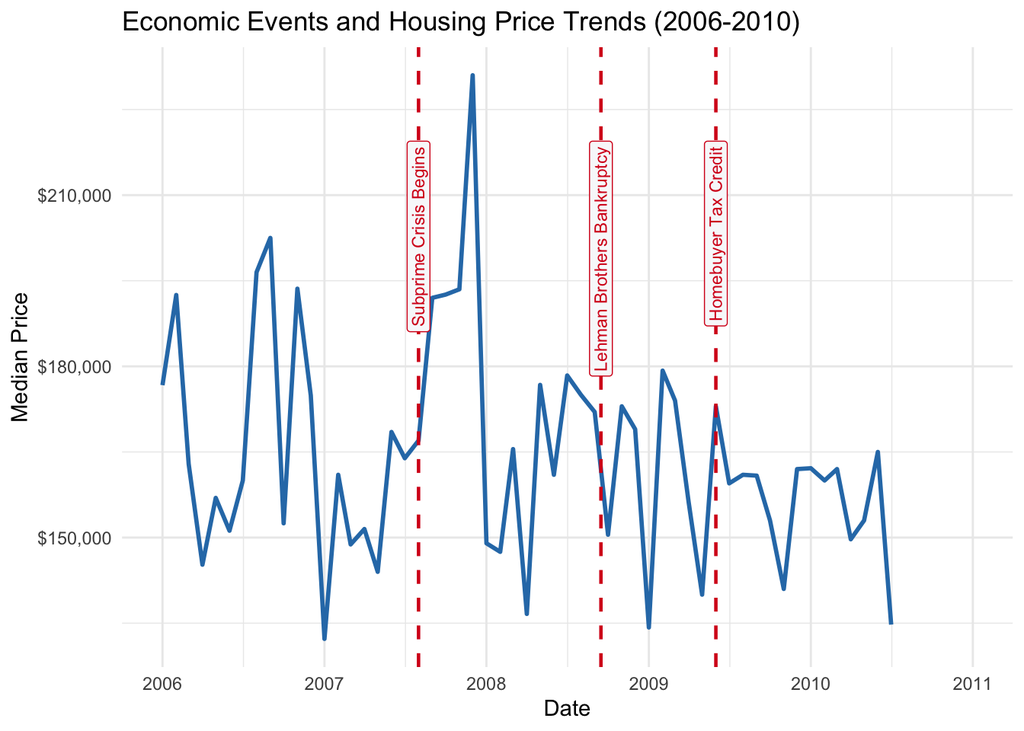

This line chart highlights the broader timeline of median sale prices from 2006 to 2010, with key economic events labeled along the top. Spikes or dips in the trend line may correlate with these milestones, suggesting possible cause-and-effect relationships in the housing market.

#### 4.4.5.1 Lag Effect of Lehman Brothers Bankruptcy

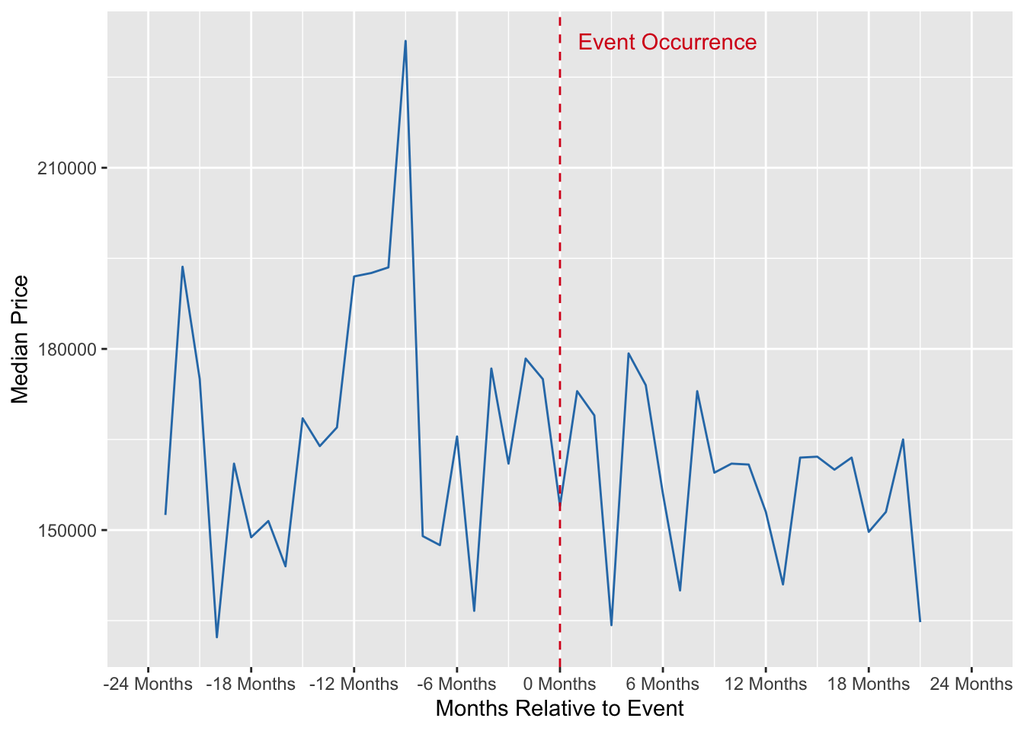

Marked by the red dashed line, this plot shows median sale prices in the months before and after the Lehman Brothers bankruptcy. The aim is to detect any delayed impact on housing values following this significant financial collapse.

#### 4.4.5.2 Figure 3: Lag Effect of Homebuyer Tax Credit

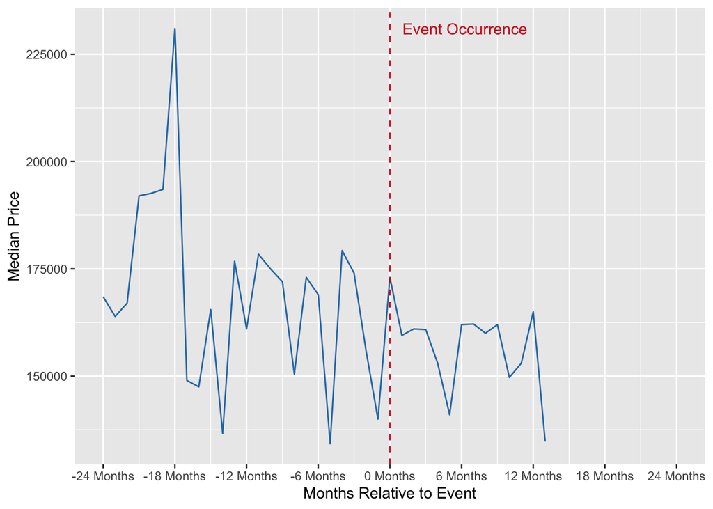

Centered on the tax credit event (red dashed line), this chart tracks median sale prices to see whether the introduction of the incentive had an immediate or gradual influence on home values.

#### 4.4.5.3 Figure 4: Lag Effect of Subprime Crisis

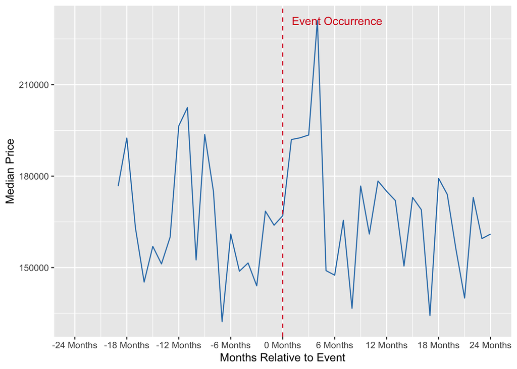

By aligning monthly median prices around the onset of the subprime crisis, this plot illustrates how housing values behaved just prior to—and in the aftermath of—this pivotal economic turning point.

## 4.5 Distributions of Key Variables

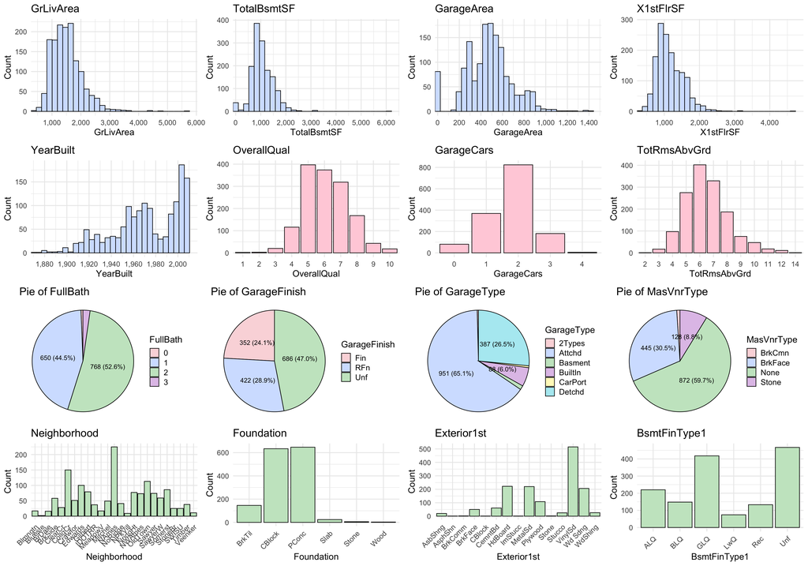

The top row shows **histograms** of various numeric features—such as `GrLivArea`, `TotalBsmtSF`, `GarageArea`, and `X1stFlrSF`—highlighting their frequency distributions. The middle row covers discrete or ordinal attributes like `YearBuilt`, `OverallQual`, and `TotRmsAbvGrd`, providing insights into how homes are spread across different quality ratings and room counts.

## 4.6 Base R Time-Series STL Decomposition

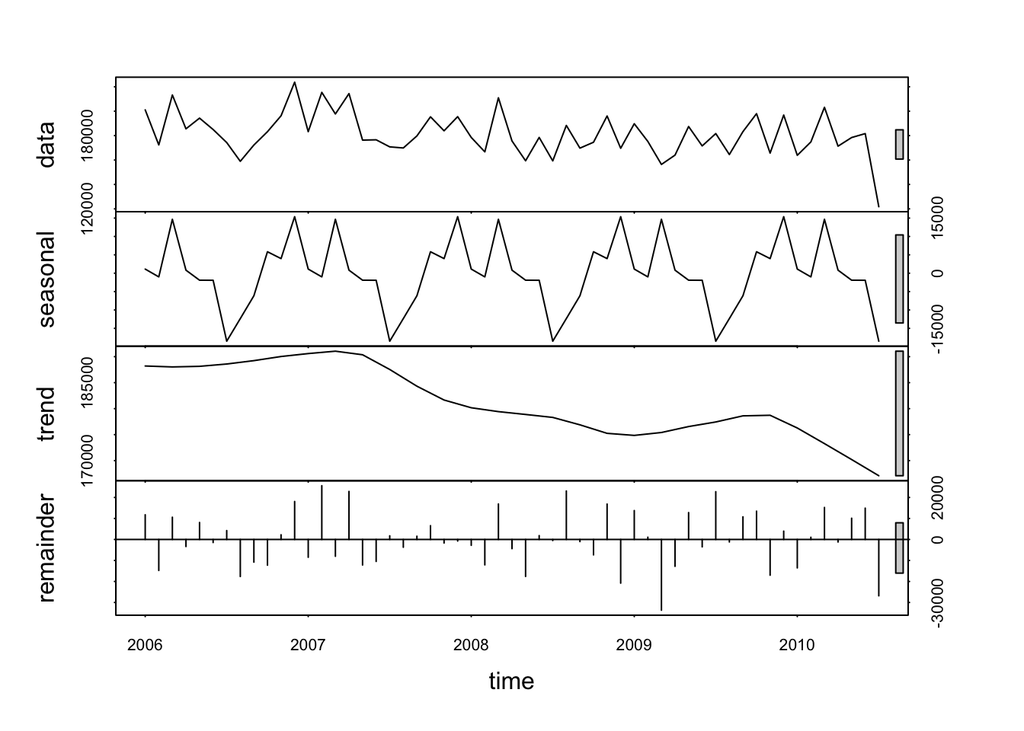

This four-panel plot displays: 1. The **raw time series data** (top panel). 2. The **seasonal component**, highlighting recurring monthly fluctuations. 3. The **trend component**, illustrating the long-term direction in house prices. 4. The **remainder** (bottom panel), capturing short-term irregularities not explained by seasonality or trend.

### 4.6.1 ggplot STL Decomposition

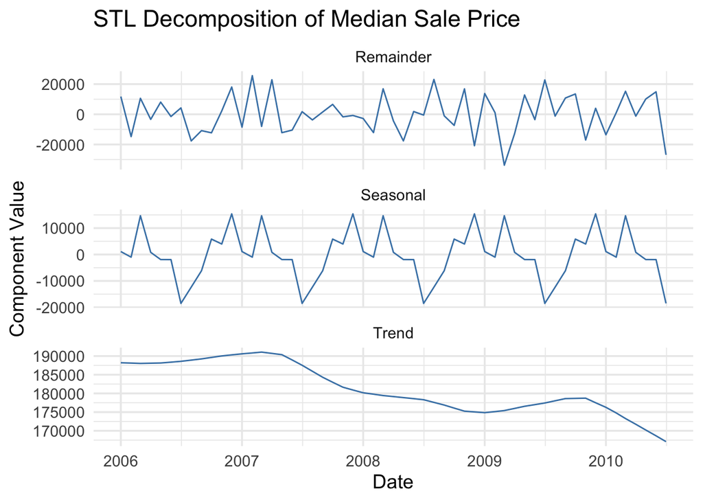

Each component—**Remainder**, **Seasonal**, and **Trend**—is shown in a separate facet, with the x-axis representing time and the y-axis showing each component’s magnitude. The **seasonal** curve exhibits regular peaks and troughs over the year, the **trend** line reveals how median sale prices evolve over time, and the **remainder** indicates any short-term fluctuations once the seasonal and trend effects have been removed.

## 4.7 Scatterplot Matrix of Selected Numeric Variables (could change)

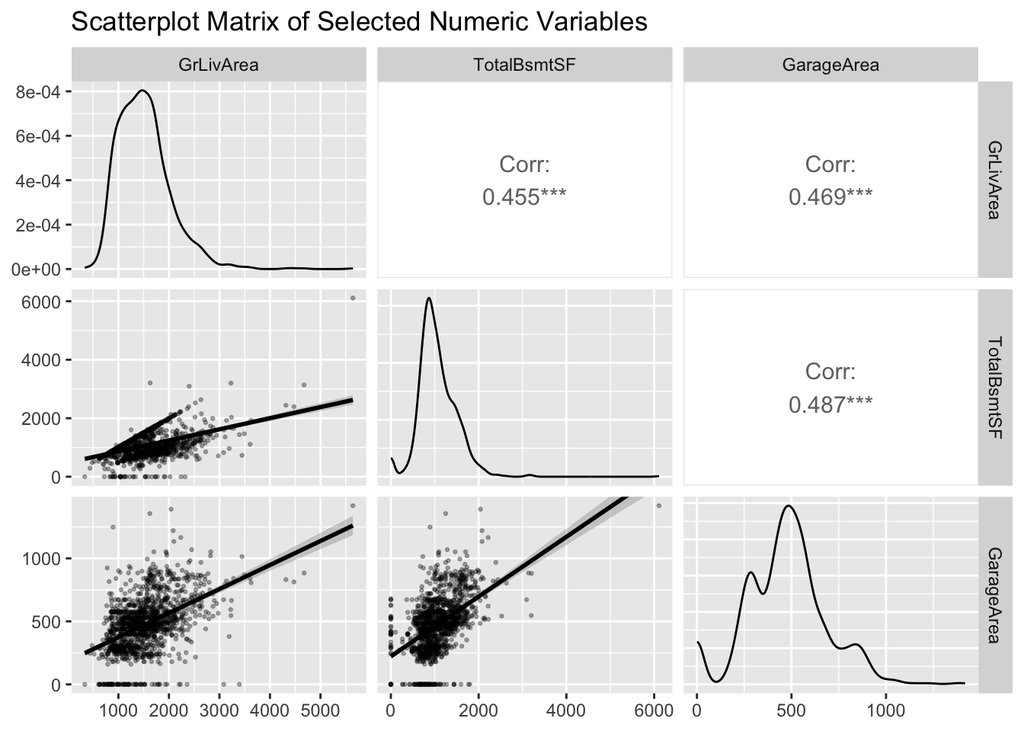

Each off-diagonal panel shows a scatterplot for a pair of numeric features (e.g., `GrLivArea` vs. `GarageArea`), while the diagonal panels display the univariate distribution of each variable (here, density plots). Correlation coefficients in the upper panels summarize the strength of each pairwise relationship, helping to identify potential outliers, clusters, and overall patterns in the data.

## 4.8 SalePrice vs. OverallQual by Neighborhood

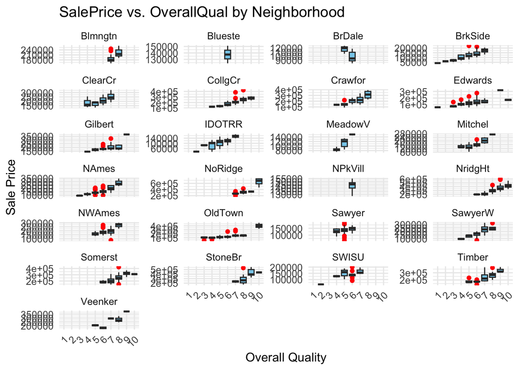

This faceted box plot displays how the distribution of sale prices changes with different overall quality ratings (`OverallQual`) across various neighborhoods. Each facet corresponds to a specific neighborhood, helping you quickly see whether high-quality homes fetch significantly higher prices in certain areas compared to others. Red points mark potential outliers, indicating unusually high or low values within each category.

## 4.9 2D Density Plot: GrLivArea vs. TotalBsmtSF (could change)

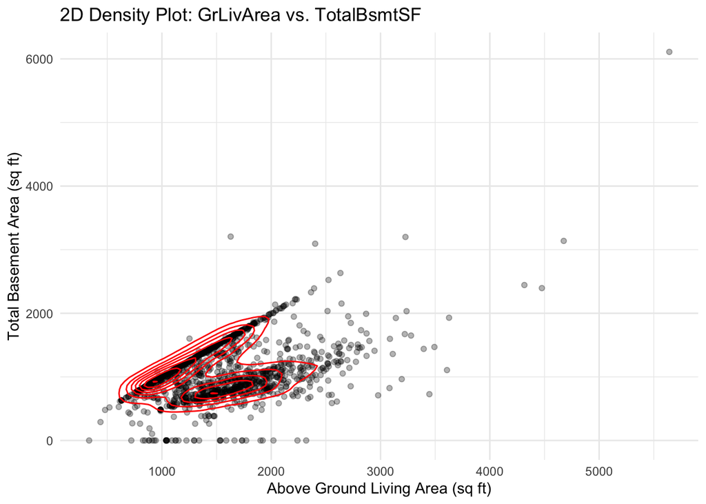

## 4.10 Hex Bin Plot: GarageArea vs. YearBuilt (could change)

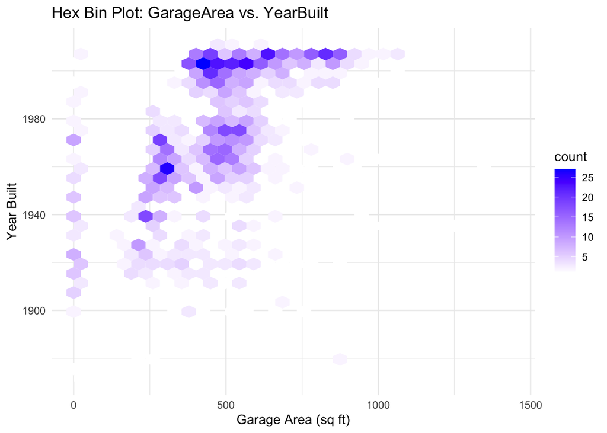

## 4.11 K-Means Clusters (k = 3) on GrLivArea vs. TotalBsmtSF (could change)

```
## 'data.frame':    1460 obs. of  4 variables:
##  $ GrLivArea  : num  1710 1262 1786 1717 2198 ...
##  $ TotalBsmtSF: num  856 1262 920 756 1145 ...
##  $ GarageArea : num  548 460 608 642 836 480 636 484 468 205 ...
##  $ OverallQual: num  7 6 7 7 8 5 8 7 7 5 ...
```

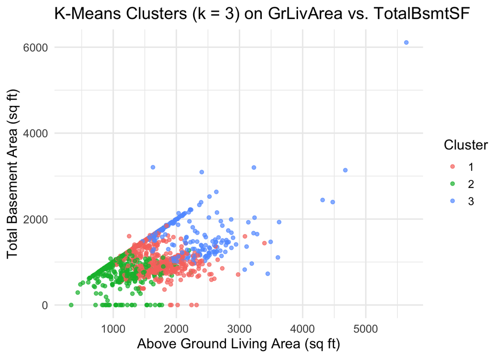

## 4.12 Parallel Coordinates Plot of K-Means Clusters (could change)

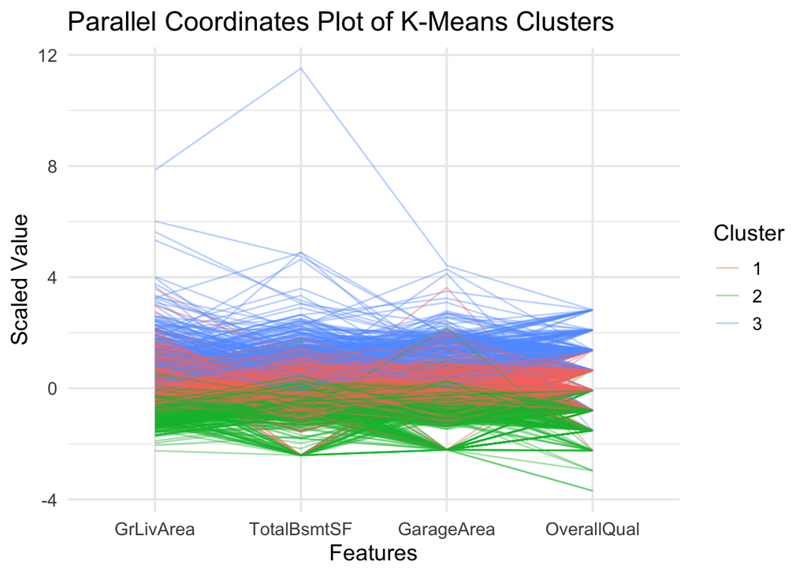

## 4.13 Clustered Neighborhoods Based on Housing Characteristics

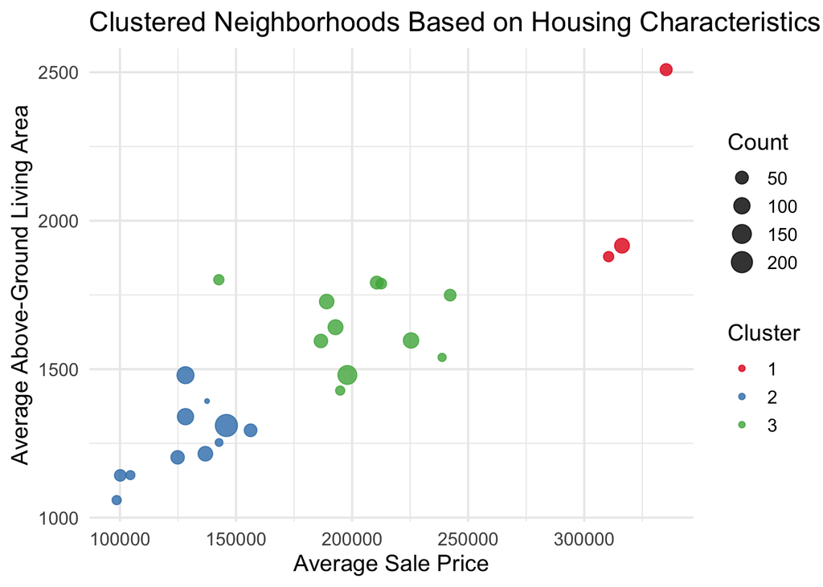

# 5 References

1. **De Cock, D. (2011).**  
   Ames, Iowa: Alternative to the Boston Housing Data as an End of Semester Regression Project.  
   *Journal of Statistics Education, 19*(3).  
   https://jse.amstat.org/v19n3/decock.pdf
2. **Sirmans, G., & Macpherson, D. A. (2003).**  
   The Value of Housing Characteristics: A Meta Analysis.  
   https://www.researchgate.net/publication/5151851_The_Value_of_Housing_Characteristics_A_Meta_Analysis
3. **NYC Data Science Academy. (2019).**  
   Analyzing Data to Predict Housing Prices in Ames, Iowa.  
   https://nycdatascience.com/blog/student-works/analyzing-data-to-predict-housing-prices-in-ames-iowa-6/
4. **El Mouna, L., Silkan, H., Haynf, Y., Nann, M. F., & Tekouabou, S. C. K. (2023).**  
   A Comparative Study of Urban House Price Prediction Using Machine Learning Algorithms.  
   *E3S Web of Conferences, 418*, 03001.  
   https://doi.org/10.1051/e3sconf/202341803001  
   Retrieved from [ResearchGate](https://www.researchgate.net/publication/373200743_A_Comparative_Study_of_Urban_House_Price_Prediction_using_Machine_Learning_Algorithms)
5. **Guo, J. (2023).**  
   Feature Selection in House Price Prediction.  
   *Highlights in Business, Economics and Management, 21*, 14755.  
   https://doi.org/10.54097/hbem.v21i.14755  
   Retrieved from [ResearchGate](https://www.researchgate.net/publication/379349464_Feature_Selection_in_House_Price_Prediction)
6. **Manasa, J., Gupta, R., & Nuggenahalli, N. S. (2020).**  
   Machine Learning Based Predicting House Prices Using Regression Techniques.  
   In *2020 2nd International Conference on Innovative Mechanisms for Industry Applications (ICIMIA)* (pp. 9074952).  
   https://doi.org/10.1109/ICIMIA48430.2020.9074952  
   Retrieved from [ResearchGate](https://www.researchgate.net/publication/340896273_Machine_Learning_based_Predicting_House_Prices_using_Regression_Techniques)
7. **Kuhn, M., & Silge, J. (2021).**  
   Tidy Modeling with R: The Ames Housing Data.  
   https://www.tmwr.org/ames